# Golden Rules for Reproducible Statistical Analyses

Amy Gimma and Thibaut Jombart

Monday 21 October 2019

# 1 Organize your document logically

## 1.1 Outline

A clear structure is essential for readers to understand and navigate your analysis document. We recommend the following structure:

- Data preparation
- Analysis of *xxx*
- Analysis of *yyy*
- …
- Export outputs
- (Optionally) System information

Where the analyses of *xxx*, *yyy*, … should have identical structures, if possible.

## 1.2 Data preparation

We recommend the following structure:

- **Load packages needed**
- **Load the raw data**
- **Clean the raw data**
  - *standardise data* (e.g. `linelist::clean_data`)
  - *convert dates* that need converting (e.g. `linelist::guess_dates`)
  - *fix typos* (e.g. `linelist::clean_variable_spelling`)
- **Add new variables** (e.g. using `mutate`)
- **Subset entries** (rows) of the data (e.g. using `filter`)
- **Define custom colors** (e.g. using `scale_fill_manual` or `scale_color_manual`)

## 1.3 Data analysis

Organise the work in a systematic way, using one sub-section per type of analysis, and starting with general analyses before subsetted or stratified ones.

The following workflow should apply to most cases:

- **Data manipulations and computations**: this part will derive numbers and metrics needed by the analysis
- **Graphics**: graphical display of the results; we recommend using *ggplot2* where possible
- **Table**: a table providing numbers matching the graphics, and useful summary statistics, e.g. means, medians, confidence intervals, etc.

## 1.4 Export outputs

As a rule, we recommend to export every table displayed in the document to a `.xlsx` and/or `.rds` files, so that they can be used in further analyses in R (`.rds` file) or using other software. (`.xlsx` file). We recommend `.xlsx` over text-based formats (e.g. `.txt`, `.csv`) as it preserves variable types.

```r
## create the produced_xlsx folder if it does not exist
if (!dir.exists("produced_xlsx")) {
  dir.create("produced_xlsx")
}

## vector of names of tables to export
## (these need to be existing data.frames or tibbles)
to_export <- c("table_1",
               "table_xxx",
               "table_yyy",
               "table_zzz")

## export all files
for (e in to_export) {
  rio::export(get(e),
              file.path("produced_xlsx",
                        paste0(e, ".xlsx")))
}
```

The following code will create links in your document pointing to the exported files:

```r
## note: for this to work, use the options `results = "asis"` and
## `echo = FALSE` in the code chunk header
for (e in to_export) {
  txt <- sprintf("- [%s.xlsx](%s.xlsx)",
                 e,
                 file.path("produced_xlsx",
                           e))
  cat(txt, sep = "\n")
}
```

## 1.5 System information

This is optional, but can be useful for audit purposes, or for diagnosing issues in the results generated. We recommend including the following:

- `Sys.info()`: basic system information
- `R.version`: version of **R**
- `sessionInfo()`: which packages are loaded, and which versions are they?
- `params`: this list will contain optional parameters passed at compilation time through the `params` argument of `compile_report` or `update_reports`

# 2 Follow standard naming conventions

## 2.1 Outline

Consistent and predictable naming helps streamline writing and reviewing code. We recommend using the following conventions, already used to a large extent in package development:

- **use only**: lower case letters, numbers, and `_` as separator (only use `-` for dates)
- **never use**: special characters in file names, variable names or values such as `éÈçôï\/# %?!&:;,@*^` and blank spaces
- if you really need to, only **use special characters only when defining labels** for graphics or tables
- **for dates**: use the format `yyyy-mm-dd`, e.g. `2001-10-13` for the 13th October
- **for encoding**: use `UTF-8` encoding whenever possible, as it guarantees that special characters will display correctly on different computers

Note that all of these points, except for the encoding, will be achieved by using `linelist::clean_data` on your `data.frame` or `tibble`.

## 2.2 Example1: clean *vs* messy

The following data is messy for many reasons, as it violates all the above:

```r
messy <- linelist::messy_data(n = 10) %>% select(1:5)
messy
##       'ID Date of Onset. DisCharge.. GENDER_  Épi.Case_définition
## 1  zhpmio     2018-01-10  20/01/2018   Female         suspected
## 2  sckroc     2018-01-04  14/01/2018     Male          not a case
## 3  snwdom     2018-01-11  21/01/2018   female         suspected
## 4  kheaqv     2018-01-08  18/01/2018     MALE         suspected
## 5  papdba     2018-01-11  21/01/2018   Female         suspected
## 6  pypdsv     2018-01-02  12/01/2018     MALE         suspected
## 7  cyuiex     2018-01-05  15/01/2018   Female         suspected
## 8  koexkj     2018-01-08  18/01/2018     Male           Confirmed
## 9  uuljge     2018-01-02  12/01/2018   FEMALE          not a case
## 10 nuqiit     2018-01-02  12/01/2018     MALE            probable
```

A clean version of this would be:

```r
clean <- clean_data(messy)
clean
##        id date_of_onset  discharge gender epi_case_definition
## 1  zhpmio    2018-01-10 2018-01-20 female           suspected
## 2  sckroc    2018-01-04 2018-01-14   male          not_a_case
## 3  snwdom    2018-01-11 2018-01-21 female           suspected
## 4  kheaqv    2018-01-08 2018-01-18   male           suspected
## 5  papdba    2018-01-11 2018-01-21 female           suspected
## 6  pypdsv    2018-01-02 2018-01-12   male           suspected
## 7  cyuiex    2018-01-05 2018-01-15 female           suspected
## 8  koexkj    2018-01-08 2018-01-18   male           confirmed
## 9  uuljge    2018-01-02 2018-01-12 female          not_a_case
## 10 nuqiit    2018-01-02 2018-01-12   male            probable
```

## 2.3 Example 2: special characters in graphics

Here we show how we can make exceptions to the naming conventions when displaying graphics, without actually altering the data. We use the Korean MERS dataset from the [*outbreaks*](https://www.repidemicsconsortium.org/outbreaks) package, and use French labels to justify the accents:

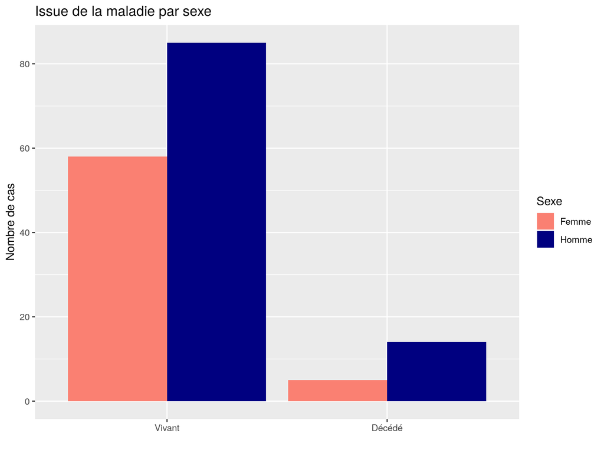

```r
## load and clean data
mers <- outbreaks::mers_korea_2015$linelist %>%
  as_tibble() %>%
  clean_data()

mers
## # A tibble: 162 x 15
##    id      age age_class sex   place_infect reporting_ctry loc_hosp
##    <chr> <int> <chr>     <fct> <fct>        <fct>          <fct>
##  1 sk_1     68 60_69     m     middle_east  south_korea    pyeongt…
##  2 sk_2     63 60_69     f     outside_mid… south_korea    pyeongt…
##  3 sk_3     76 70_79     m     outside_mid… south_korea    pyeongt…
##  4 sk_4     46 40_49     f     outside_mid… south_korea    pyeongt…
##  5 sk_5     50 50_59     m     outside_mid… south_korea    365_yeo…
##  6 sk_6     71 70_79     m     outside_mid… south_korea    pyeongt…
##  7 sk_7     28 20_29     f     outside_mid… south_korea    pyeongt…
##  8 sk_8     46 40_49     f     outside_mid… south_korea    seoul_c…
##  9 sk_9     56 50_59     m     outside_mid… south_korea    pyeongt…
## 10 sk_10    44 40_49     m     outside_mid… china          pyeongt…
## # … with 152 more rows, and 8 more variables: dt_onset <date>,
## #   dt_report <date>, week_report <fct>, dt_start_exp <date>,
## #   dt_end_exp <date>, dt_diag <date>, outcome <fct>, dt_death <date>

## define scales for sex and outcome, tweak labels as appropriate
scale_sex <- scale_fill_manual(
    "Sexe",
    values = c(m = "navy", f = "salmon"),
    labels = c(m = "Homme", f = "Femme"))

scale_x_outcome <- scale_x_discrete(
    labels = c(alive = "Vivant",
               dead = "Décédé"))

## make the plot
ggplot(mers, aes(x = outcome, fill = sex)) +
  geom_bar(position = "dodge") +
  scale_sex +
  scale_x_outcome +
  labs(title = "Issue de la maladie par sexe",
       x = "",
       y = "Nombre de cas")
```

Here, we are using accents, spaces, and upper-case letters for the graphics, but because we restrict these to labels used in `scales`, the data remain clean, respecting naming conventions.

# 3 Use descriptive naming

## 3.1 Outline

All files and **R** objects should be named in an explicit way. There is a trade-off between the length of a variable and explicit naming, but clarity is often, if not always preferrable. Some exceptions can be made, e.g. by systematically calling `x` your data.

## 3.2 Example

Here is an example of poor naming:

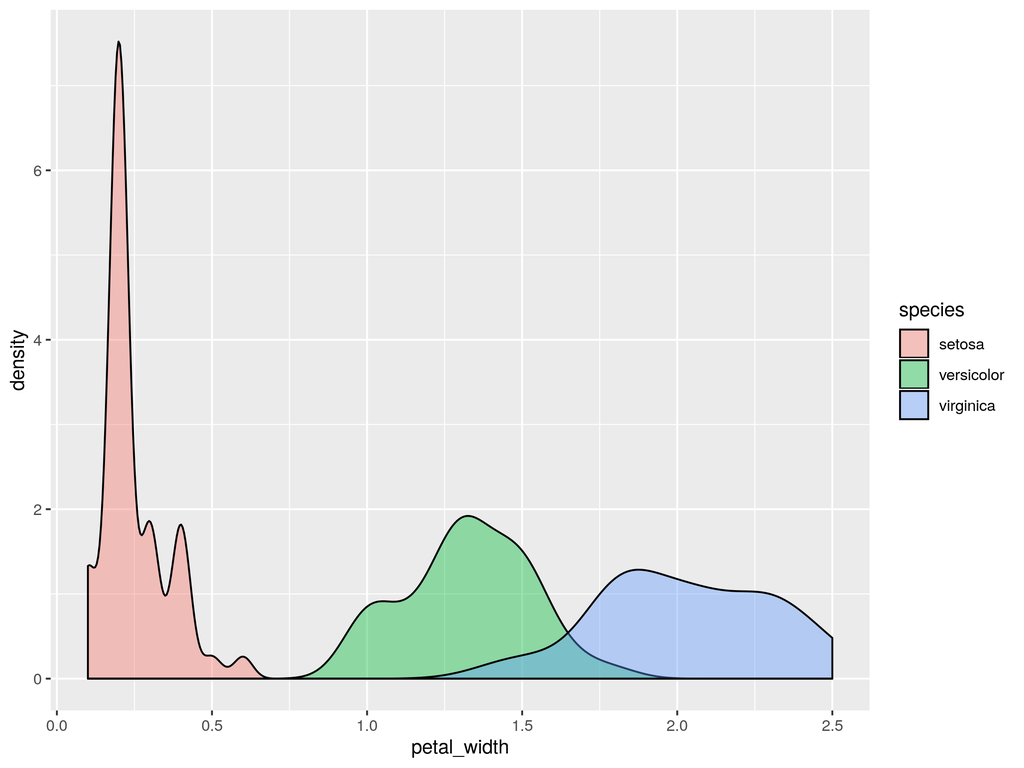

```r
i <- iris %>%
  clean_data()
tab <- i %>%
  count(species)
tab
## # A tibble: 3 x 2
##   species        n
##   <fct>      <int>
## 1 setosa        50
## 2 versicolor    50
## 3 virginica     50

tab_2 <- i %>%
  group_by(species) %>%
  summarise_all(mean)
tab_2
## # A tibble: 3 x 5
##   species    sepal_length sepal_width petal_length petal_width
##   <fct>             <dbl>       <dbl>        <dbl>       <dbl>
## 1 setosa             5.01        3.43         1.46       0.246
## 2 versicolor         5.94        2.77         4.26       1.33
## 3 virginica          6.59        2.97         5.55       2.03


a <- ggplot(i, aes(x = petal_width)) +
  geom_density(aes(fill = species), alpha = .4)
a
```

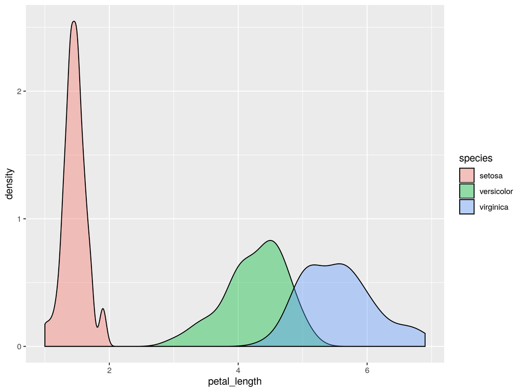

```r
b <- ggplot(i, aes(x = petal_length)) +
  geom_density(aes(fill = species), alpha = .4)
b
```

This code is bad because:

- `iris`, the name of the dataset, is uselessly renamed to `i`, with no indication that the data has been cleaned
- `tab` and `tab_2` suggest these are *tables*, but provides no indication as to what they contain
- `a` and `b` are plots, but the name does not indicate that they are, or what the plots are about

A better version would be:

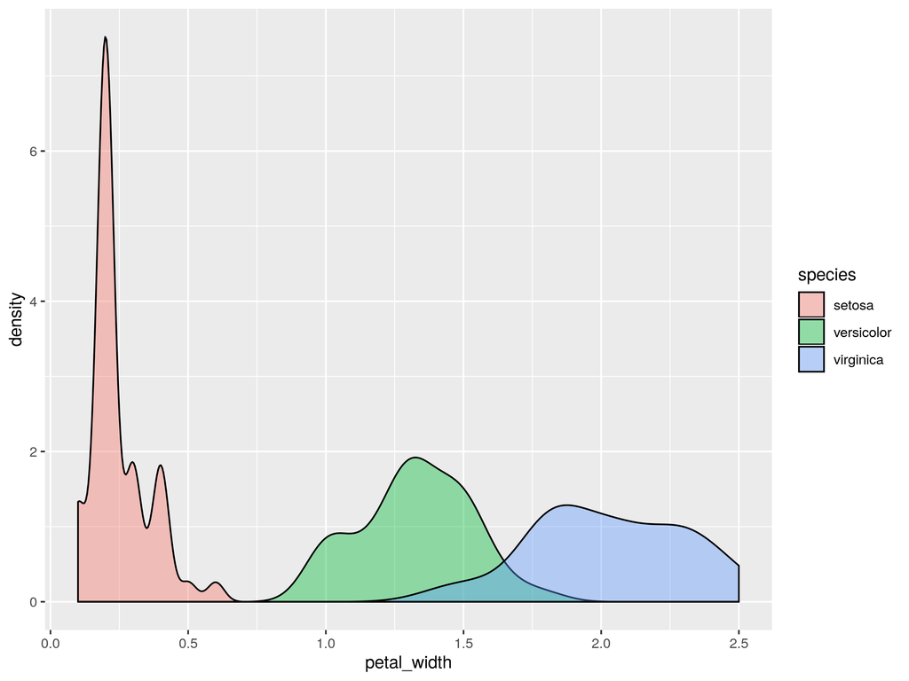

```r
iris_clean <- iris %>%
  clean_data()

table_species_counts <- iris_clean %>%
  count(species)
table_species_counts
## # A tibble: 3 x 2
##   species        n
##   <fct>      <int>
## 1 setosa        50
## 2 versicolor    50
## 3 virginica     50

table_species_means <- iris_clean %>%
  group_by(species) %>%
  summarise_all(mean)
table_species_means
## # A tibble: 3 x 5
##   species    sepal_length sepal_width petal_length petal_width
##   <fct>             <dbl>       <dbl>        <dbl>       <dbl>
## 1 setosa             5.01        3.43         1.46       0.246
## 2 versicolor         5.94        2.77         4.26       1.33
## 3 virginica          6.59        2.97         5.55       2.03

plot_petal_width <- ggplot(iris_clean, aes(x = petal_width)) +
  geom_density(aes(fill = species), alpha = .4)
plot_petal_width
```

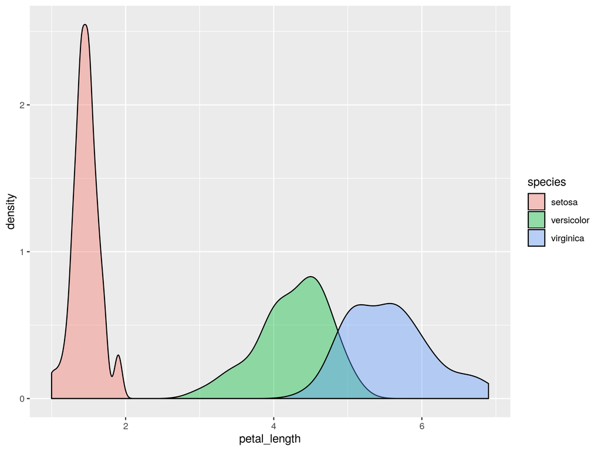

```r
plot_petal_length <- ggplot(iris_clean, aes(x = petal_length)) +
  geom_density(aes(fill = species), alpha = .4)
plot_petal_length
```

# 4 Write simple, readable code

## 4.1 Outline

Writing simple code is essential for enabling others (and in fact, yourself) to read and understand your code, identify possible issues, or propose improvements. Good code should be simple to read and understand. Here are some guidelines for producing simple, readable code:

- **write short lines** (ideally less than 80 characters); many short lines are much easier to read than a single, long line of code
- **use intermediate variables**, e.g. when subsetting data, finding indices of items to modify; define named functions rather than lambdas (i.e. anonymous, on-the-fly functions used e.g. in `lapply` or `mutate`)
- **start a new line after each piping operator `%>%`**
- **use indentation** to make the code readable
- **describe your code**: provide a plain text description of the code, using numbered steps, and then refer to these steps in the code using comments
- **use `##` for comments**, rather than a single `#` which are indented differently on different code editors

## 4.2 Example: breaking code in small bits

In this example, we use the `iris` dataset to compute summary statistics keeping only the `setosa` and `versicolor` species, for sepal measurements. First, some nasty version:

```r
lapply(iris_clean[iris_clean$species%in%c("setosa","versicolor"),grep("sepal",names(iris_clean))],summary)
## $sepal_length
##    Min. 1st Qu.  Median    Mean 3rd Qu.    Max.
##   4.300   5.000   5.400   5.471   5.900   7.000
##
## $sepal_width
##    Min. 1st Qu.  Median    Mean 3rd Qu.    Max.
##   2.000   2.800   3.050   3.099   3.400   4.400
```

The task is simple, but the code already complicated as too many things are nested within the same line. Also note the absence of spaces after `,` and operators, which makes the code less readable. The same code can be rewritten in a much clearer way, first using base R:

```r
## find rows to keep: species setosa and versicolor
rows_to_keep <- iris_clean$species %in% c("setosa", "versicolor")

## identify columns with 'sepal' in their name
sepal_columns <- grep("sepal", names(iris_clean))

## subset data to analyse
sepals_setosa_versicolor <- iris_clean[rows_to_keep, sepal_columns]

## get summaries
lapply(sepals_setosa_versicolor, summary)
## $sepal_length
##    Min. 1st Qu.  Median    Mean 3rd Qu.    Max.
##   4.300   5.000   5.400   5.471   5.900   7.000
##
## $sepal_width
##    Min. 1st Qu.  Median    Mean 3rd Qu.    Max.
##   2.000   2.800   3.050   3.099   3.400   4.400
```

A variant using `dplyr` would be:

```r
iris_clean %>%
  filter(species %in% c("setosa","versicolor")) %>%
  select(contains("sepal")) %>%
  lapply(summary)
## $sepal_length
##    Min. 1st Qu.  Median    Mean 3rd Qu.    Max.
##   4.300   5.000   5.400   5.471   5.900   7.000
##
## $sepal_width
##    Min. 1st Qu.  Median    Mean 3rd Qu.    Max.
##   2.000   2.800   3.050   3.099   3.400   4.400
```

## 4.3 Example: useless complexity

Here we show some examples of un-needed complexity:

```r
## task: finding female, confirmed cases in x which have incompatible
## admission / discharge dates
timing_errors <- x %>%
  filter(!((date_admission < date_discharge) %in% TRUE) & (case_type %in% "confirmed") & !is.na(sex) & sex == "female")
```

```r
## alternative version: finding female, confirmed cases in x which have
## incompatible admission / discharge dates
timing_errors <- x %>%
  filter(date_admission >= date_discharge,
         case_type == "confirmed",
         sex == "female")
```

## 4.4 Example: fixing typos / recoding variables

In this example, we recode values of a variable `sex` with different mis-spellings, using different approaches, starting with a complicated one.

```r
values <- c("m", NA, "Male", "fem", "F", "female", "male", "femme")
x <- data.frame(sex = sample(values, 20, replace = TRUE))
x
##       sex
## 1    <NA>
## 2     fem
## 3       m
## 4    <NA>
## 5    <NA>
## 6       F
## 7       F
## 8    Male
## 9    <NA>
## 10   Male
## 11   Male
## 12      F
## 13   male
## 14    fem
## 15    fem
## 16 female
## 17      F
## 18   Male
## 19   male
## 20   male

## one-line version - ugly
x %>% mutate(sex_clean = ifelse(sex == "m", "male", ifelse(is.na(sex), "unknown", ifelse(sex == "Male", "male", ifelse(sex == "fem", "female", ifelse(sex == "F", "female", ifelse(sex == "female", "female", ifelse(sex == "femme", "female", ifelse(sex == "male", "male", NA_character_)))))))))
##       sex sex_clean
## 1    <NA>      <NA>
## 2     fem    female
## 3       m      male
## 4    <NA>      <NA>
## 5    <NA>      <NA>
## 6       F    female
## 7       F    female
## 8    Male      male
## 9    <NA>      <NA>
## 10   Male      male
## 11   Male      male
## 12      F    female
## 13   male      male
## 14    fem    female
## 15    fem    female
## 16 female    female
## 17      F    female
## 18   Male      male
## 19   male      male
## 20   male      male
```

```r
## variant with indentation - still bad
x %>% mutate(sex_clean = ifelse(sex == "m", "male",
                           ifelse(is.na(sex), "unknown",
                             ifelse(sex == "Male", "male",
                               ifelse(sex == "fem", "female",
                                 ifelse(sex == "F", "female",
                                   ifelse(sex == "female", "female",
                                     ifelse(sex == "femme", "female",
                                       ifelse(sex == "male", "male", NA_character_)))))))))
##       sex sex_clean
## 1    <NA>      <NA>
## 2     fem    female
## 3       m      male
## 4    <NA>      <NA>
## 5    <NA>      <NA>
## 6       F    female
## 7       F    female
## 8    Male      male
## 9    <NA>      <NA>
## 10   Male      male
## 11   Male      male
## 12      F    female
## 13   male      male
## 14    fem    female
## 15    fem    female
## 16 female    female
## 17      F    female
## 18   Male      male
## 19   male      male
## 20   male      male
```

The code above works, but is utterly unreadable, even when indented properly. This causes multiple problems:

- near **impossible to identify mistakes** as the code is very hard to digest
- **very hard to expand** the code to account for new typos
- code produced is very long, which means **doing this for multiple variables and typos will be a problem**

As a rule, nested `ifelse` statements should always be avoided. As a replacement, one can use `case_when`:

```r
x %>% mutate(sex_clean = case_when(
                 sex == "m" ~ "male",
                 sex == "Male" ~ "male",
                 sex == "fem" ~ "female",
                 sex == "F" ~ "female",
                 sex == "femme" ~ "female",
                 sex == "female" ~ "female",
                 sex == "male" ~ "male",
                 TRUE ~ NA_character_
             ))
##       sex sex_clean
## 1    <NA>      <NA>
## 2     fem    female
## 3       m      male
## 4    <NA>      <NA>
## 5    <NA>      <NA>
## 6       F    female
## 7       F    female
## 8    Male      male
## 9    <NA>      <NA>
## 10   Male      male
## 11   Male      male
## 12      F    female
## 13   male      male
## 14    fem    female
## 15    fem    female
## 16 female    female
## 17      F    female
## 18   Male      male
## 19   male      male
## 20   male      male
```

This code is simpler and more readable, but can still be improved. Yet another alternative is offered by `linelist::clean_data`, which can use cleaning rules to fix typos or recode variables. The procedure includes:

1. standardising data using `clean_data` to remove capitalisation issues, which simplifies the cleaning rules (e.g. no need to change `Male` to `male`)
2. defining cleaning rules for a variable (ideally in a separate Excel spreadsheet); note that because `clean_variable_spelling` already standardises entries, all spelling will be in lower-case,
3. apply these cleaning rules to the variable using `linelist::clean_spelling`

Let us illustrate this:

```r
## load and show cleaning rules
cleaning_rules_file <- here::here("data", "cleaning_rules.xlsx")
cleaning_rules <- rio::import(cleaning_rules_file)
cleaning_rules
##       typo correction variable
## 1        m       male      sex
## 2      fem     female      sex
## 3        f     female      sex
## 4    femme     female      sex
## 5 .missing    unknown      sex

## clean data and apply cleaning rules
x %>%
  clean_data() %>%
  mutate(sex_clean = clean_spelling(sex, wordlist = cleaning_rules))
##       sex sex_clean
## 1    <NA>   unknown
## 2     fem    female
## 3       m      male
## 4    <NA>   unknown
## 5    <NA>   unknown
## 6       f    female
## 7       f    female
## 8    male      male
## 9    <NA>   unknown
## 10   male      male
## 11   male      male
## 12      f    female
## 13   male      male
## 14    fem    female
## 15    fem    female
## 16 female    female
## 17      f    female
## 18   male      male
## 19   male      male
## 20   male      male
```

In practice, cleaning rules can be passed to `clean_data` directly, in which cases variables for which cleaning rules are defined will be automatically cleaned:

```r
## generate clean dataset
x_clean <- x %>%
  clean_data(wordlists = cleaning_rules)

## compare old `x` and `x_clean`
cbind(x, x_clean)
##       sex     sex
## 1    <NA> unknown
## 2     fem  female
## 3       m    male
## 4    <NA> unknown
## 5    <NA> unknown
## 6       F  female
## 7       F  female
## 8    Male    male
## 9    <NA> unknown
## 10   Male    male
## 11   Male    male
## 12      F  female
## 13   male    male
## 14    fem  female
## 15    fem  female
## 16 female  female
## 17      F  female
## 18   Male    male
## 19   male    male
## 20   male    male
```

# 5 Code systematically

## 5.1 Outline

Be consistent in functions in libraries used

- *use `linelist::clean_data`* with a data dictionary for cleaning dates, column names and values, etc. Take the time to understand how to use this package and how it works.
- for example choose between `n()`, `tally()`, and `count()` when summarizing grouped data

## 5.2 Example

Let’s look at some basic code to count cases by location, gender and outcomes on the MERS dataset from the `outbreaks` package.

```r
mers <- outbreaks::mers_korea_2015$linelist %>%
  as_tibble()

# 2x2 table 1: location / sex
mers %>%
  group_by(place_infect, sex) %>%
  summarise(n = n())
## # A tibble: 3 x 3
## # Groups:   place_infect [2]
##   place_infect        sex       n
##   <fct>               <fct> <int>
## 1 Middle East         M         1
## 2 Outside Middle East F        63
## 3 Outside Middle East M        98

## 2x2 table 2: location / outcome
loc_out_tab <- count(mers, place_infect, outcome)
loc_out_tab
## # A tibble: 3 x 3
##   place_infect        outcome     n
##   <fct>               <fct>   <int>
## 1 Middle East         Alive       1
## 2 Outside Middle East Alive     142
## 3 Outside Middle East Dead       19

##################################
## 2x2 table 3: location / outcome
##################################
table_sex_outcome <- with(mers, table(sex, outcome)) %>% as.data.frame() %>% as_tibble
table_sex_outcome
## # A tibble: 4 x 3
##   sex   outcome  Freq
##   <fct> <fct>   <int>
## 1 F     Alive      58
## 2 M     Alive      85
## 3 F     Dead        5
## 4 M     Dead       14
```

The code is correct, but there are plenty of consistency issues here; to name a few:

- using 3 different approaches to construct the 2x2 tables
- not using the piping operator `%>%` in table 2, but using it elsewhere
- annotations are not consistent
- not going back to a new line after the piping operators for table 3
- in table 3, not using parenthesis for `as_tibble`, but using them for `as.data.frame()`
- storing the 2nd and 3rd table as objects, but not for the 1st one
- using different naming conventions: table 2 is abbreviated and `tab` comes last, whilst table 3 is explicit and `table` comes first in the name

A more consistent version of the code would look like:

```r
## 2x2 table 1: location / sex
table_location_sex <- mers %>%
  count(place_infect, sex)
table_location_sex
## # A tibble: 3 x 3
##   place_infect        sex       n
##   <fct>               <fct> <int>
## 1 Middle East         M         1
## 2 Outside Middle East F        63
## 3 Outside Middle East M        98

## 2x2 table 2: location / outcome
table_location_outcome <- mers %>%
  count(place_infect, outcome)
table_location_outcome
## # A tibble: 3 x 3
##   place_infect        outcome     n
##   <fct>               <fct>   <int>
## 1 Middle East         Alive       1
## 2 Outside Middle East Alive     142
## 3 Outside Middle East Dead       19

## 2x2 table 3: location / outcome
table_sex_outcome <- mers %>%
  count(sex, outcome)
table_sex_outcome
## # A tibble: 4 x 3
##   sex   outcome     n
##   <fct> <fct>   <int>
## 1 F     Alive      58
## 2 F     Dead        5
## 3 M     Alive      85
## 4 M     Dead       14
```

# 6 Show statistical variation / uncertainty

## 6.1 Outline

Variation in the data as well as the uncertainty associated to point estimates (e.g. mean, proportion, etc) always need to be accounted for when analysing data. Lack of doing so often leads to over-interpreting patterns, or to seeing trends where there are, in fact, none.

Some guidelines can be used to avoid such issues:

- try to always plot the raw data before using summary statistics
- never plot results of a linear model / smoother / trend curve alone, but add it to the data
- when comparing summary statistics (e.g. mean, proportions) across different time points or groups, use confidence intervals to show the uncertainty associated with the estimation of these statistic; if unsure whether a confidence interval is needed, go through the decision tree below

```
 -------------------------    |Yes|----- **Include Confidence Interval**
|                         |     |
|     Might the value     |     |
| observed be different   |-----|
| with a larger sample?   |     |                 |Yes|--| **CI not required**
|                         |     |    -----------   |
 -------------------------    |No|--| You sure? |--|
                                     -----------   |
                                                  |No|-- **Ask a statistician!**
```

## 6.2 Example: showing variation in the data

Let us make some toy data, and plot a trend **without showing dispersion** in the data:

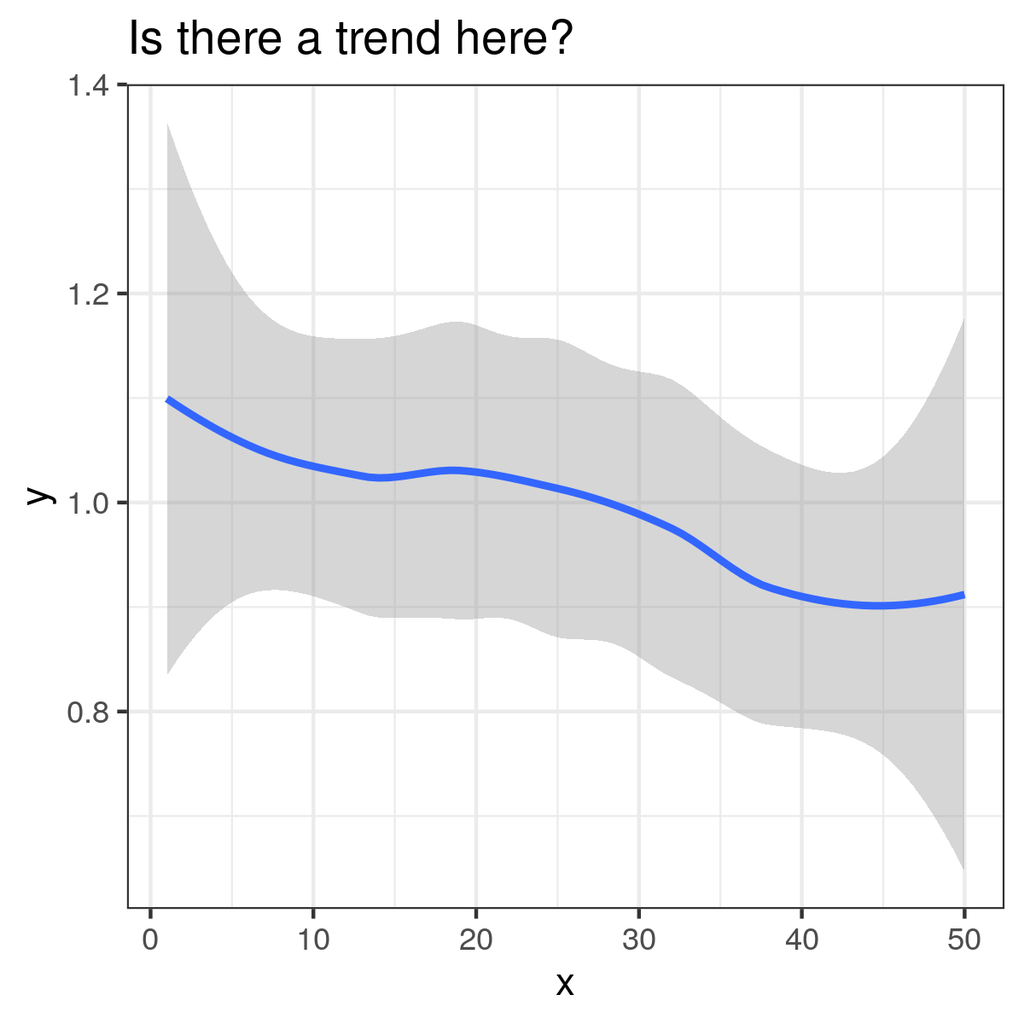

```r
set.seed(1)
x <- rep(1:50, each = 15)
y <- rnorm(length(x), mean = 1)
df <- data.frame(x, y)

ggplot(df, aes(x = x, y = y)) +
  theme_bw() +
  geom_smooth() +
  labs(title = "Is there a trend here?")
```

Looking at this graph, **we may think there is a downward trend**, and start interpreting what it means etc. **In fact, this is purely artifactual**. Data have been generated in such a way that there is no correlation between the two variables. This would be obvious if we add the data, thereby representing the variability in the data:

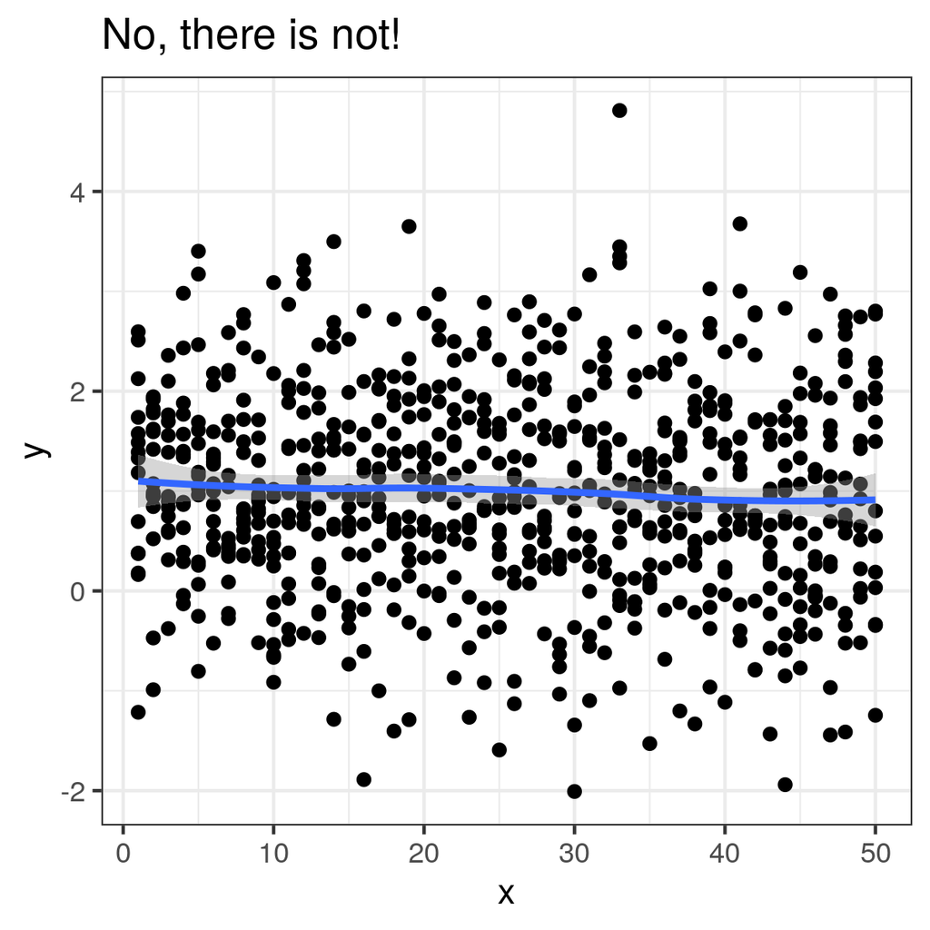

```r
ggplot(df, aes(x = x, y = y)) +
  theme_bw() +
  geom_point() +
  geom_smooth() +
  labs(title = "No, there is not!")
```

# 7 Always use relative paths

## 7.1 Outline

Absolute paths point to a specific locationn on one’s computer. Most likely, this path exists only on this computer, so that files and folders referred this way will not exist on other computers.

The alternative is to use relative path, i.e. path defined respective to a given location, typically the project folder. These paths will work on any computer which possess a copy of the project folder. Relative path are best set using the `here` library with R project files to establish a root directory.

## 7.2 Example

```r
## Bad practice:
x <- read.csv("C:/user/john_doe/secret_project/data/data_raw.csv")

## Good practice, after opening R in `secret_project`:
path_to_data <- here::here("data", "data_raw.csv")
x <- read.csv(path_to_data)
```

# 8 Version and archive documents

Use semantic versioning in a clearly organized, standardized file structure

```
.
+-- linelist_investigations
|   +-- css
|   +-- data
|   +-- report_outputs
|   +-- report_sources
|       +-- aaa_clean_linelist_2019-29-09.Rmd
|       +-- epicurve_2019-04-10.Rmd
|       +-- _archive
|           +-- epicurve_2019-23-09.Rmd
|           +-- epicurve_2019-12-09.Rmd
```

# 9 Prepare presentation-ready plots

**Plots should be ready to copy and paste into an official presentation**

- check labels for correct spelling, accents, and grammar
- uniform colors for variables throughout a document
- text size large
- avoid overlapping labels or other features

# 10 Always have your code reviewed

Ensure that:

- Analysis is appropriate to setting and underlying data is well understood, local collaborators should be included and acknowledged
- statistical methodology is applied correctly
- R code is readable and correctly implements methodology
- markdown and the report document are well organized and properly formatted

# 11 Keep data safe

- Respect the privacy of the individuals described in the data
- Never label data as anonomysed without complying with best practices of the standards and methods of anonymyzation (and clear final product with a qualified statistician)